# Removing correlation for baseline prediction study in a more principled way

I think it makes sense to remove the data in a more principled way. First, remove obivous outliers from the normal distributions. Then, remove based on movement and bad slices until we get rid of the correlation.

```r
library(gdata)
demo = read.xls('~/philip/long_scans_08072018.xlsx', sheet='dti')
df = read.csv('~/philip/dti_long.csv')
colnames(demo)[1] ='MRN'
df2 = merge(df, demo, by.x = 'mask.id', by.y='Mask.ID')
dim(df2)
```

```
[1] 751  59
```

Now remove outliers in each of the normal distributions:

```r
mult = 2
hist(df2$mean_fa, breaks=50)
ll = mean(df2$mean_fa) - mult*sd(df2$mean_fa)
ul = mean(df2$mean_fa) + mult*sd(df2$mean_fa)
abline(v = ll, col='red')
```

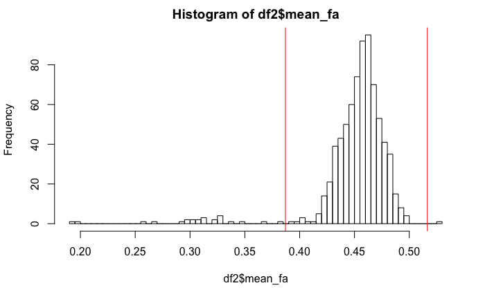

```r
abline(v = ul, col='red')
```

```r
idx_fa = df2$mean_fa < ul & df2$mean_fa > ll
# hist(df2$mean_ad, breaks=50)
# idx5 = df2$mean_ad < 1.45 & df2$mean_ad > 1.15
# hist(df2$mean_rd, breaks=50)
# idx6 = df2$mean_rd < .65 & df2$mean_rd > .5
# idx = idx1 & idx2 & idx3 & idx4 & idx5 & idx6
# sum(idx)
```

```r
mult = 2
hist(df2$mean_ad, breaks=50)
ll = mean(df2$mean_ad) - mult*sd(df2$mean_ad)
ul = mean(df2$mean_ad) + mult*sd(df2$mean_ad)
abline(v = ll, col='red')
```

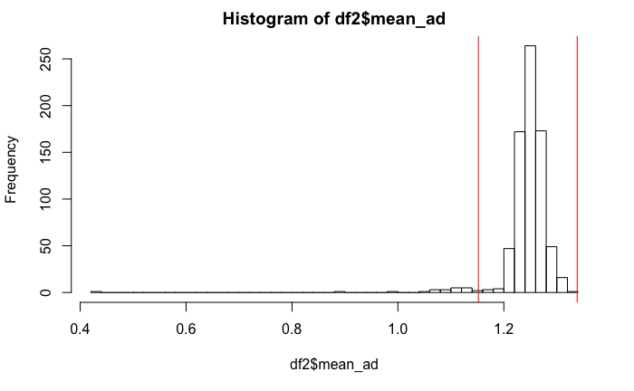

```r
abline(v = ul, col='red')
```

```r
idx_ad = df2$mean_ad < ul & df2$mean_ad > ll
# hist(df2$mean_ad, breaks=50)
# idx5 = df2$mean_ad < 1.45 & df2$mean_ad > 1.15
# hist(df2$mean_rd, breaks=50)
# idx6 = df2$mean_rd < .65 & df2$mean_rd > .5
# idx = idx1 & idx2 & idx3 & idx4 & idx5 & idx6
# sum(idx)
```

```r
mult = 2
hist(df2$mean_rd, breaks=50)
ll = mean(df2$mean_rd) - mult*sd(df2$mean_rd)
ul = mean(df2$mean_rd) + mult*sd(df2$mean_rd)
abline(v = ll, col='red')
```

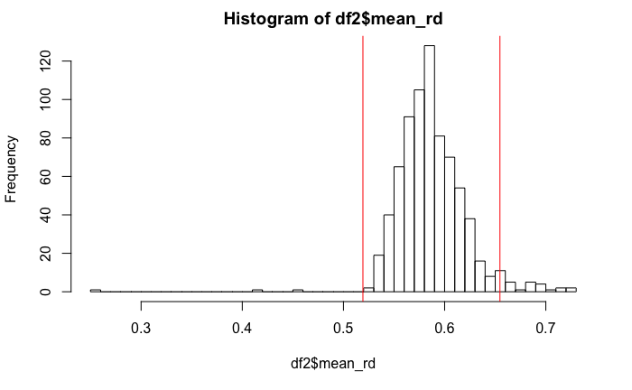

```r
abline(v = ul, col='red')
```

```r
idx_rd = df2$mean_rd < ul & df2$mean_rd > ll
# hist(df2$mean_ad, breaks=50)
# idx5 = df2$mean_ad < 1.45 & df2$mean_ad > 1.15
# hist(df2$mean_rd, breaks=50)
# idx6 = df2$mean_rd < .65 & df2$mean_rd > .5
# idx = idx1 & idx2 & idx3 & idx4 & idx5 & idx6
# sum(idx)
```

```r
idx = idx_fa & idx_ad & idx_rd
df3 = df2[idx,]
dim(df3)
```

```
[1] 719  59
```

Maybe we also include a check on goodVolumes?

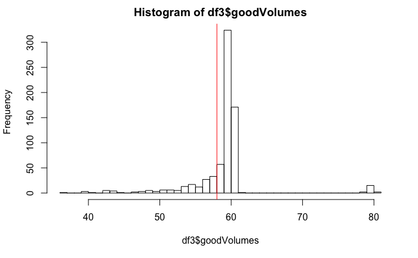

```r
mult = 2
hist(df3$goodVolumes, breaks=50)
abline(v = 58, col='red')
```

```r
df3 = df3[df3$goodVolumes >=58,]
```

OK, now we have removed the bad scans based on distribution. Now, let’s pick the first one for each subject, and remove them sequentially according to movement:

```r
source('~/research_code/baseline_prediction/aux_functions.R', echo=TRUE)
```

```
> # figure out the baseline scans. For 9 months, min_time_diff = .75
> get_single_scans = function(data, min_time_diff=0, last_scan=F) {
+     keep =  .... [TRUNCATED]
```

```r
df = get_single_scans(df3, last_scan=F)
dim(df)
```

```
[1] 297  59
```

```r
cor.test(df$norm.trans, df$mean_fa)
```

```
    Pearson's product-moment correlation

data:  df$norm.trans and df$mean_fa
t = 1.0587, df = 295, p-value = 0.2906
alternative hypothesis: true correlation is not equal to 0
95 percent confidence interval:
 -0.05265521  0.17411857
sample estimates:
       cor
0.06152566
```

```r
cor.test(df$norm.trans, df$mean_ad)
```

```
    Pearson's product-moment correlation

data:  df$norm.trans and df$mean_ad
t = 1.4257, df = 295, p-value = 0.155
alternative hypothesis: true correlation is not equal to 0
95 percent confidence interval:
 -0.03138646  0.19470030
sample estimates:
       cor
0.08272119
```

```r
cor.test(df$norm.trans, df$mean_rd)
```

```
    Pearson's product-moment correlation

data:  df$norm.trans and df$mean_rd
t = -0.35086, df = 295, p-value = 0.7259
alternative hypothesis: true correlation is not equal to 0
95 percent confidence interval:
 -0.13392424  0.09360635
sample estimates:
        cor
-0.02042339
```

```r
cor.test(df$norm.rot, df$mean_fa)
```

```
    Pearson's product-moment correlation

data:  df$norm.rot and df$mean_fa
t = -0.033061, df = 295, p-value = 0.9736
alternative hypothesis: true correlation is not equal to 0
95 percent confidence interval:
 -0.1157117  0.1119118
sample estimates:
         cor
-0.001924873
```

```r
cor.test(df$norm.rot, df$mean_ad)
```

```
    Pearson's product-moment correlation

data:  df$norm.rot and df$mean_ad
t = -0.0075269, df = 295, p-value = 0.994
alternative hypothesis: true correlation is not equal to 0
95 percent confidence interval:
 -0.1142447  0.1133796
sample estimates:
          cor
-0.0004382311
```

```r
cor.test(df$norm.rot, df$mean_rd)
```

```
    Pearson's product-moment correlation

data:  df$norm.rot and df$mean_rd
t = -0.095397, df = 295, p-value = 0.9241
alternative hypothesis: true correlation is not equal to 0
95 percent confidence interval:
 -0.1192909  0.1083265
sample estimates:
         cor
-0.005554152
```

Actually, there was no correlation at p=.05… do we need to still remove it? Let’s merge it with clinical because maybe after removing other scans some correlation to movement might creep in:

```r
dim(df)
```

```
[1] 297  59
```

```r
clin = read.csv('~/philip/long_clin_0815.csv')
dim(clin)
```

```
[1] 380  13
```

```r
m = merge(df,clin)
dim(m)
```

```
[1] 291  71
```

```r
scan_date = as.Date(as.character(m$record.date.collected...Scan), format='%m/%d/%Y')
doa_date = as.Date(as.character(m$last_DOA), format='%m/%d/%Y')
d = doa_date - scan_date
sum(d > 30*6)
```

```
[1] 270
```

```r
sum(d > 30*12)
```

```
[1] 263
```

OK, so let’s see if we have correlations using any of those subject sets:

```r
cor.test(m$norm.trans, m$mean_fa)
```

```
    Pearson's product-moment correlation

data:  m$norm.trans and m$mean_fa
t = 1.1941, df = 289, p-value = 0.2334
alternative hypothesis: true correlation is not equal to 0
95 percent confidence interval:
 -0.04527932  0.18356900
sample estimates:
       cor
0.07006668
```

```r
cor.test(m$norm.trans, m$mean_ad)
```

```
    Pearson's product-moment correlation

data:  m$norm.trans and m$mean_ad
t = 1.3555, df = 289, p-value = 0.1763
alternative hypothesis: true correlation is not equal to 0
95 percent confidence interval:
 -0.03582778  0.19270102
sample estimates:
       cor
0.07948086
```

```r
cor.test(m$norm.trans, m$mean_rd)
```

```
    Pearson's product-moment correlation

data:  m$norm.trans and m$mean_rd
t = -0.4739, df = 289, p-value = 0.6359
alternative hypothesis: true correlation is not equal to 0
95 percent confidence interval:
 -0.14239035  0.08739588
sample estimates:
        cor
-0.02786535
```

```r
cor.test(m$norm.rot, m$mean_fa)
```

```
    Pearson's product-moment correlation

data:  m$norm.rot and m$mean_fa
t = 0.34265, df = 289, p-value = 0.7321
alternative hypothesis: true correlation is not equal to 0
95 percent confidence interval:
 -0.09504988  0.13482041
sample estimates:
       cor
0.02015157
```

```r
cor.test(m$norm.rot, m$mean_ad)
```

```
    Pearson's product-moment correlation

data:  m$norm.rot and m$mean_ad
t = -0.18327, df = 289, p-value = 0.8547
alternative hypothesis: true correlation is not equal to 0
95 percent confidence interval:
 -0.1256055  0.1043305
sample estimates:
        cor
-0.01078001
```

```r
cor.test(m$norm.rot, m$mean_rd)
```

```
    Pearson's product-moment correlation

data:  m$norm.rot and m$mean_rd
t = -0.4663, df = 289, p-value = 0.6414
alternative hypothesis: true correlation is not equal to 0
95 percent confidence interval:
 -0.14195261  0.08783923
sample estimates:
        cor
-0.02741892
```

So, if we only check the subjects that have some clinical, out of the ones with good data, there is nol correlation between movement and mean variables. But since we’re only worried about later assessments, let’s dig further:

```r
idx = d > 30*6
sum(idx)
```

```
[1] 270
```

```r
cor.test(m[idx,]$norm.trans, m[idx,]$mean_fa)
```

```
    Pearson's product-moment correlation

data:  m[idx, ]$norm.trans and m[idx, ]$mean_fa
t = 1.1841, df = 268, p-value = 0.2374
alternative hypothesis: true correlation is not equal to 0
95 percent confidence interval:
 -0.04764222  0.18988454
sample estimates:
       cor
0.07214398
```

```r
cor.test(m[idx,]$norm.trans, m[idx,]$mean_ad)
```

```
    Pearson's product-moment correlation

data:  m[idx, ]$norm.trans and m[idx, ]$mean_ad
t = 0.65151, df = 268, p-value = 0.5153
alternative hypothesis: true correlation is not equal to 0
95 percent confidence interval:
 -0.07998966  0.15838995
sample estimates:
       cor
0.03976595
```

```r
cor.test(m[idx,]$norm.trans, m[idx,]$mean_rd)
```

```
    Pearson's product-moment correlation

data:  m[idx, ]$norm.trans and m[idx, ]$mean_rd
t = -0.78756, df = 268, p-value = 0.4316
alternative hypothesis: true correlation is not equal to 0
95 percent confidence interval:
 -0.16647328  0.07173505
sample estimates:
        cor
-0.04805233
```

```r
cor.test(m[idx,]$norm.rot, m[idx,]$mean_fa)
```

```
    Pearson's product-moment correlation

data:  m[idx, ]$norm.rot and m[idx, ]$mean_fa
t = 0.42736, df = 268, p-value = 0.6695
alternative hypothesis: true correlation is not equal to 0
95 percent confidence interval:
 -0.09357097  0.14502053
sample estimates:
       cor
0.02609642
```

```r
cor.test(m[idx,]$norm.rot, m[idx,]$mean_ad)
```

```
    Pearson's product-moment correlation

data:  m[idx, ]$norm.rot and m[idx, ]$mean_ad
t = -0.54723, df = 268, p-value = 0.5847
alternative hypothesis: true correlation is not equal to 0
95 percent confidence interval:
 -0.15217796  0.08631113
sample estimates:
        cor
-0.03340899
```

```r
cor.test(m[idx,]$norm.rot, m[idx,]$mean_rd)
```

```
    Pearson's product-moment correlation

data:  m[idx, ]$norm.rot and m[idx, ]$mean_rd
t = -0.66385, df = 268, p-value = 0.5074
alternative hypothesis: true correlation is not equal to 0
95 percent confidence interval:
 -0.1591238  0.0792416
sample estimates:
        cor
-0.04051757
```

If we only use the 270 subjects with clinical assessment at least 6 months after scan, also no correlation.

```r
idx = d > 30*12
sum(idx)
```

```
[1] 263
```

```r
cor.test(m[idx,]$norm.trans, m[idx,]$mean_fa)
```

```
    Pearson's product-moment correlation

data:  m[idx, ]$norm.trans and m[idx, ]$mean_fa
t = 1.1843, df = 261, p-value = 0.2374
alternative hypothesis: true correlation is not equal to 0
95 percent confidence interval:
 -0.04827498  0.19236422
sample estimates:
      cor
0.0731086
```

```r
cor.test(m[idx,]$norm.trans, m[idx,]$mean_ad)
```

```
    Pearson's product-moment correlation

data:  m[idx, ]$norm.trans and m[idx, ]$mean_ad
t = 0.71747, df = 261, p-value = 0.4737
alternative hypothesis: true correlation is not equal to 0
95 percent confidence interval:
 -0.07700353  0.16444062
sample estimates:
       cor
0.04436639
```

```r
cor.test(m[idx,]$norm.trans, m[idx,]$mean_rd)
```

```
    Pearson's product-moment correlation

data:  m[idx, ]$norm.trans and m[idx, ]$mean_rd
t = -0.80098, df = 261, p-value = 0.4239
alternative hypothesis: true correlation is not equal to 0
95 percent confidence interval:
 -0.16946018  0.07186867
sample estimates:
        cor
-0.04951849
```

```r
cor.test(m[idx,]$norm.rot, m[idx,]$mean_fa)
```

```
    Pearson's product-moment correlation

data:  m[idx, ]$norm.rot and m[idx, ]$mean_fa
t = 0.31675, df = 261, p-value = 0.7517
alternative hypothesis: true correlation is not equal to 0
95 percent confidence interval:
 -0.1015951  0.1402267
sample estimates:
      cor
0.0196025
```

```r
cor.test(m[idx,]$norm.rot, m[idx,]$mean_ad)
```

```
    Pearson's product-moment correlation

data:  m[idx, ]$norm.rot and m[idx, ]$mean_ad
t = -0.35934, df = 261, p-value = 0.7196
alternative hypothesis: true correlation is not equal to 0
95 percent confidence interval:
 -0.14280991  0.09898558
sample estimates:
        cor
-0.02223735
```

```r
cor.test(m[idx,]$norm.rot, m[idx,]$mean_rd)
```

```
    Pearson's product-moment correlation

data:  m[idx, ]$norm.rot and m[idx, ]$mean_rd
t = -0.51999, df = 261, p-value = 0.6035
alternative hypothesis: true correlation is not equal to 0
95 percent confidence interval:
 -0.15253315  0.08913352
sample estimates:
     cor
-0.03217
```

If we only use the 263 subjects with clinical assessment at least 12 months after scan, also no correlation.

And just to be on the safe side, let’s run spearman correlations too:

```r
cor.test(m$norm.trans, m$mean_fa, method='spearman')
```

```
Cannot compute exact p-value with ties
```

```
    Spearman's rank correlation rho

data:  m$norm.trans and m$mean_fa
S = 3982500, p-value = 0.6067
alternative hypothesis: true rho is not equal to 0
sample estimates:
       rho
0.03029964
```

```r
cor.test(m$norm.trans, m$mean_ad, method='spearman')
```

```
Cannot compute exact p-value with ties
```

```
    Spearman's rank correlation rho

data:  m$norm.trans and m$mean_ad
S = 4005200, p-value = 0.6737
alternative hypothesis: true rho is not equal to 0
sample estimates:
       rho
0.02478442
```

```r
cor.test(m$norm.trans, m$mean_rd, method='spearman')
```

```
    Spearman's rank correlation rho

data:  m$norm.trans and m$mean_rd
S = 4136300, p-value = 0.9034
alternative hypothesis: true rho is not equal to 0
sample estimates:
         rho
-0.007139553
```

```r
cor.test(m$norm.rot, m$mean_fa, method='spearman')
```

```
Cannot compute exact p-value with ties
```

```
    Spearman's rank correlation rho

data:  m$norm.rot and m$mean_fa
S = 3933300, p-value = 0.4723
alternative hypothesis: true rho is not equal to 0
sample estimates:
       rho
0.04229946
```

```r
cor.test(m$norm.rot, m$mean_ad, method='spearman')
```

```
Cannot compute exact p-value with ties
```

```
    Spearman's rank correlation rho

data:  m$norm.rot and m$mean_ad
S = 4061600, p-value = 0.8511
alternative hypothesis: true rho is not equal to 0
sample estimates:
      rho
0.0110529
```

```r
cor.test(m$norm.rot, m$mean_rd, method='spearman')
```

```
    Spearman's rank correlation rho

data:  m$norm.rot and m$mean_rd
S = 4164700, p-value = 0.8111
alternative hypothesis: true rho is not equal to 0
sample estimates:
        rho
-0.01406338
```

```r
idx = d > 30*6
sum(idx)
```

```
[1] 270
```

```r
cor.test(m[idx,]$norm.trans, m[idx,]$mean_fa, method='spearman')
```

```
Cannot compute exact p-value with ties
```

```
    Spearman's rank correlation rho

data:  m[idx, ]$norm.trans and m[idx, ]$mean_fa
S = 3156400, p-value = 0.5362
alternative hypothesis: true rho is not equal to 0
sample estimates:
       rho
0.03780452
```

```r
cor.test(m[idx,]$norm.trans, m[idx,]$mean_ad, method='spearman')
```

```
Cannot compute exact p-value with ties
```

```
    Spearman's rank correlation rho

data:  m[idx, ]$norm.trans and m[idx, ]$mean_ad
S = 3310000, p-value = 0.8829
alternative hypothesis: true rho is not equal to 0
sample estimates:
         rho
-0.009002114
```

```r
cor.test(m[idx,]$norm.trans, m[idx,]$mean_rd, method='spearman')
```

```
    Spearman's rank correlation rho

data:  m[idx, ]$norm.trans and m[idx, ]$mean_rd
S = 3364500, p-value = 0.6748
alternative hypothesis: true rho is not equal to 0
sample estimates:
        rho
-0.02562907
```

```r
cor.test(m[idx,]$norm.rot, m[idx,]$mean_fa, method='spearman')
```

```
Cannot compute exact p-value with ties
```

```
    Spearman's rank correlation rho

data:  m[idx, ]$norm.rot and m[idx, ]$mean_fa
S = 3108000, p-value = 0.3896
alternative hypothesis: true rho is not equal to 0
sample estimates:
       rho
0.05256315
```

```r
cor.test(m[idx,]$norm.rot, m[idx,]$mean_ad, method='spearman')
```

```
Cannot compute exact p-value with ties
```

```
    Spearman's rank correlation rho

data:  m[idx, ]$norm.rot and m[idx, ]$mean_ad
S = 3340700, p-value = 0.764
alternative hypothesis: true rho is not equal to 0
sample estimates:
        rho
-0.01835479
```

```r
cor.test(m[idx,]$norm.rot, m[idx,]$mean_rd, method='spearman')
```

```
    Spearman's rank correlation rho

data:  m[idx, ]$norm.rot and m[idx, ]$mean_rd
S = 3384500, p-value = 0.6035
alternative hypothesis: true rho is not equal to 0
sample estimates:
        rho
-0.03172944
```

```r
idx = d > 30*12
sum(idx)
```

```
[1] 263
```

```r
cor.test(m[idx,]$norm.trans, m[idx,]$mean_fa, method='spearman')
```

```
Cannot compute exact p-value with ties
```

```
    Spearman's rank correlation rho

data:  m[idx, ]$norm.trans and m[idx, ]$mean_fa
S = 2923100, p-value = 0.5624
alternative hypothesis: true rho is not equal to 0
sample estimates:
       rho
0.03588157
```

```r
cor.test(m[idx,]$norm.trans, m[idx,]$mean_ad, method='spearman')
```

```
Cannot compute exact p-value with ties
```

```
    Spearman's rank correlation rho

data:  m[idx, ]$norm.trans and m[idx, ]$mean_ad
S = 3030100, p-value = 0.9927
alternative hypothesis: true rho is not equal to 0
sample estimates:
        rho
0.000567968
```

```r
cor.test(m[idx,]$norm.trans, m[idx,]$mean_rd, method='spearman')
```

```
    Spearman's rank correlation rho

data:  m[idx, ]$norm.trans and m[idx, ]$mean_rd
S = 3096000, p-value = 0.7325
alternative hypothesis: true rho is not equal to 0
sample estimates:
        rho
-0.02115926
```

```r
cor.test(m[idx,]$norm.rot, m[idx,]$mean_fa, method='spearman')
```

```
Cannot compute exact p-value with ties
```

```
    Spearman's rank correlation rho

data:  m[idx, ]$norm.rot and m[idx, ]$mean_fa
S = 2895300, p-value = 0.4669
alternative hypothesis: true rho is not equal to 0
sample estimates:
      rho
0.0450581
```

```r
cor.test(m[idx,]$norm.rot, m[idx,]$mean_ad, method='spearman')
```

```
Cannot compute exact p-value with ties
```

```
    Spearman's rank correlation rho

data:  m[idx, ]$norm.rot and m[idx, ]$mean_ad
S = 3044500, p-value = 0.9463
alternative hypothesis: true rho is not equal to 0
sample estimates:
         rho
-0.004175983
```

```r
cor.test(m[idx,]$norm.rot, m[idx,]$mean_rd, method='spearman')
```

```
    Spearman's rank correlation rho

data:  m[idx, ]$norm.rot and m[idx, ]$mean_rd
S = 3096300, p-value = 0.7314
alternative hypothesis: true rho is not equal to 0
sample estimates:
        rho
-0.02124831
```